# L2_Investing_Globally

FIN 3380: Introduction to Financial Data Analysis

Week 3-4

# Load Packages

```r
setwd("C:/Users/siche/Documents/teaching/Introduction to Financial Data Analysis/L2")
library(RPostgres)
library(tidyr)
library(dplyr)
```

# Step 1: Get unique index id: the gvkeyx from WRDS Compustat database COMP.G_IDX_INDEX

```r
# connect to WRDS
source("C:/Users/siche/Documents/teaching/wrds.R")
```

```r
# create quote for the following tics to get gvkeyx(the unique index id in compustat database)

tics = paste0(c("I3DEU003","I3FRA006","I6UNK059",
                "I3GBR049","I3GBR050","I3GBR053",
                "I2IND004","I3TUR001","I2KOR003",
                "I2AUS006","I2HKG004","I2JPN006"),
              collapse = "','")
tics
```

```
## [1] "I3DEU003','I3FRA006','I6UNK059','I3GBR049','I3GBR050','I3GBR053','I2IND004','I3TUR001','I2KOR003','I2AUS006','I2HKG004','I2JPN006"
```

```r
q = paste0("select conm,gvkeyx,tic from COMP.G_IDX_INDEX where tic in ('",tics,"')")
q
```

```
## [1] "select conm,gvkeyx,tic from COMP.G_IDX_INDEX where tic in ('I3DEU003','I3FRA006','I6UNK059','I3GBR049','I3GBR050','I3GBR053','I2IND004','I3TUR001','I2KOR003','I2AUS006','I2HKG004','I2JPN006')"
```

```r
res = dbSendQuery(wrds,q)
ind.g = dbFetch(res, n=-1)
dbClearResult(res)
save(ind.g,file='ind.g.RData')
```

```r
head(ind.g)
```

```
##                   conm gvkeyx      tic
## 1  Composite DAX Index 150007 I3DEU003
## 2       FTSE 100 Index 150008 I3GBR049
## 3        BSE 100 Index 150012 I2IND004
## 4       FTSE 250 Index 150013 I3GBR050
## 5 ISE 100 Index-Turkey 150018 I3TUR001
## 6     CAC All Tradable 150021 I3FRA006
```

# Step 2: Get the historical monthly close price of each index from WRDS compustat database

```r
# select distinct gvkeyx and use paste to prepare the string for sql quote
gvkeyx = unique(ind.g$gvkeyx)
gvkeyx = paste0(gvkeyx,collapse = "','")
gvkeyx
```

```
## [1] "150007','150008','150012','150013','150018','150021','150035','150036','150042','150051','150069','150376"
```

```r
# create the sql quote
q = paste0("select gvkeyx,datadate,prccm from COMP.G_IDX_MTH where gvkeyx in ('",
           gvkeyx,"') and datadate>'2000-12-31'")
q
```

```
## [1] "select gvkeyx,datadate,prccm from COMP.G_IDX_MTH where gvkeyx in ('150007','150008','150012','150013','150018','150021','150035','150036','150042','150051','150069','150376') and datadate>'2000-12-31'"
```

```r
res = dbSendQuery(wrds, q)
ind.g.price = dbFetch(res, n=-1)
dbClearResult(res)
save(ind.g.price,file='ind.g.price.RData')
```

```r
head(ind.g.price)
```

```
##   gvkeyx   datadate  prccm
## 1 150007 2001-01-31 531.61
## 2 150007 2001-02-28 493.02
## 3 150007 2001-03-31 462.78
## 4 150007 2001-04-30 492.45
## 5 150007 2001-05-31 484.95
## 6 150007 2001-06-30 480.19
```

# Step 3: Yearly returns of each stock

```r
# rename the price table
colnames(ind.g.price)=c("gvkeyx","date","price")
head(ind.g.price)
```

```
##   gvkeyx       date  price
## 1 150007 2001-01-31 531.61
## 2 150007 2001-02-28 493.02
## 3 150007 2001-03-31 462.78
## 4 150007 2001-04-30 492.45
## 5 150007 2001-05-31 484.95
## 6 150007 2001-06-30 480.19
```

```r
# calculate yearly return of each index
ret.index =  ind.g.price %>%
  mutate(year = format(date,'%Y')) %>%
  group_by(gvkeyx, year) %>%
  summarise(last.price = price[length(price)]) %>%
  ungroup() %>%
  group_by(gvkeyx) %>%
  arrange(year) %>%
  mutate(ret = last.price/lag(last.price,1)-1) %>%
  ungroup() %>%
  arrange(gvkeyx,year)

head(ret.index)
```

```
## # A tibble: 6 x 4
##   gvkeyx year  last.price     ret
##   <chr>  <chr>      <dbl>   <dbl>
## 1 150007 2001        417. NA
## 2 150007 2002        251. -0.399
## 3 150007 2003        345.  0.376
## 4 150007 2004        374.  0.0847
## 5 150007 2005        480.  0.282
## 6 150007 2006        595.  0.241
```

```r
# add back the intuitive name by joining on to the ind.g
head(ind.g)
```

```
##                   conm gvkeyx      tic
## 1  Composite DAX Index 150007 I3DEU003
## 2       FTSE 100 Index 150008 I3GBR049
## 3        BSE 100 Index 150012 I2IND004
## 4       FTSE 250 Index 150013 I3GBR050
## 5 ISE 100 Index-Turkey 150018 I3TUR001
## 6     CAC All Tradable 150021 I3FRA006
```

```r
ret.index = ret.index %>% left_join(ind.g,by="gvkeyx")
head(ret.index)
```

```
## # A tibble: 6 x 6
##   gvkeyx year  last.price     ret conm                tic
##   <chr>  <chr>      <dbl>   <dbl> <chr>               <chr>
## 1 150007 2001        417. NA      Composite DAX Index I3DEU003
## 2 150007 2002        251. -0.399  Composite DAX Index I3DEU003
## 3 150007 2003        345.  0.376  Composite DAX Index I3DEU003
## 4 150007 2004        374.  0.0847 Composite DAX Index I3DEU003
## 5 150007 2005        480.  0.282  Composite DAX Index I3DEU003
## 6 150007 2006        595.  0.241  Composite DAX Index I3DEU003
```

```r
# check the whether each index has equal number of observations
ret.index %>% group_by(tic) %>% summarise(n=n())
```

```
## # A tibble: 12 x 2
##    tic          n
##    <chr>    <int>
##  1 I2AUS006    19
##  2 I2HKG004    19
##  3 I2IND004    19
##  4 I2JPN006    19
##  5 I2KOR003    19
##  6 I3DEU003    19
##  7 I3FRA006    19
##  8 I3GBR049    19
##  9 I3GBR050    19
## 10 I3GBR053    19
## 11 I3TUR001    19
## 12 I6UNK059    19
```

```r
# change the first return to 0 as we will calculate the cumulative returns later and make each cumulative return start from 1.
ret.index$ret[which(is.na(ret.index$ret))]=0
head(ret.index)
```

```
## # A tibble: 6 x 6
##   gvkeyx year  last.price     ret conm                tic
##   <chr>  <chr>      <dbl>   <dbl> <chr>               <chr>
## 1 150007 2001        417.  0      Composite DAX Index I3DEU003
## 2 150007 2002        251. -0.399  Composite DAX Index I3DEU003
## 3 150007 2003        345.  0.376  Composite DAX Index I3DEU003
## 4 150007 2004        374.  0.0847 Composite DAX Index I3DEU003
## 5 150007 2005        480.  0.282  Composite DAX Index I3DEU003
## 6 150007 2006        595.  0.241  Composite DAX Index I3DEU003
```

# Step 4. Visualise the returns of all indices using package “ggplot2”

## Use the ggplot2 package to plot the multiple lines

## ggplot(df,aes(x,y,color)) + geom_line()/geom_point()/geom_bar() + labs(x,y,title) + theme +…

- ggplot takes the a data.frame as input(df)
- aes(x,y,color) set up the x and y values in plot, when ploting multiple lines, color is the classification column
- geom_line()/geom_point()/geom_bar() indicate the plot type
- labs(x,y,title) gives the x, y, title names
- theme() to set the legend, background color, location of legend, etc…

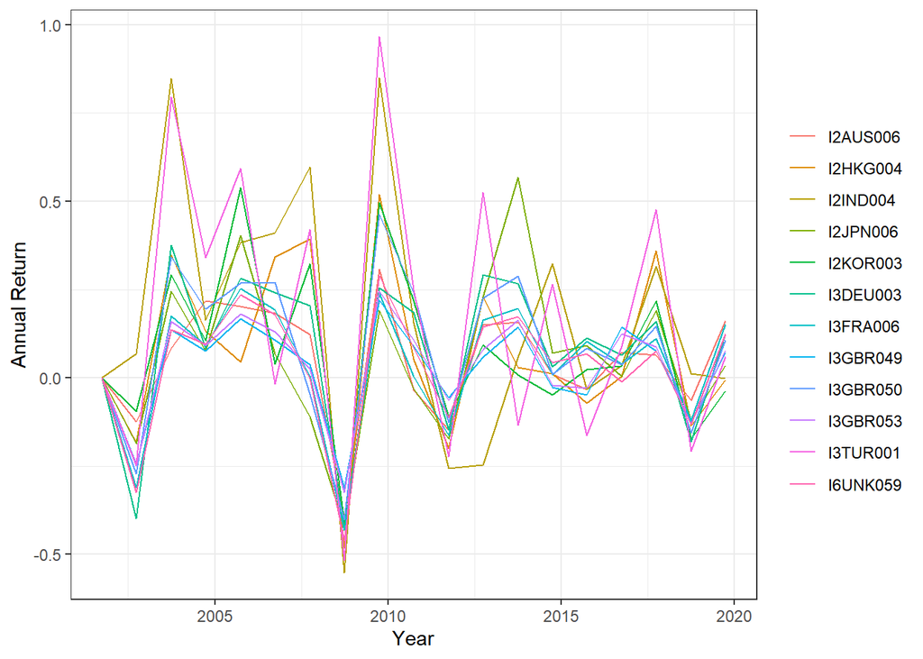

```r
library(ggplot2)
p = ggplot(ret.index,
           aes(x=as.Date(year,"%Y"),
               y=ret,
               color=tic))
p = p + geom_line()
p = p + labs(x='Year', y = 'Annual Return')
p = p + theme(legend.position="bottom") + theme_bw()
p = p + theme(legend.title=element_blank())
print(p)
```

## Benifit of ggplot is the pipeline: combine data manipulation and plotting function together

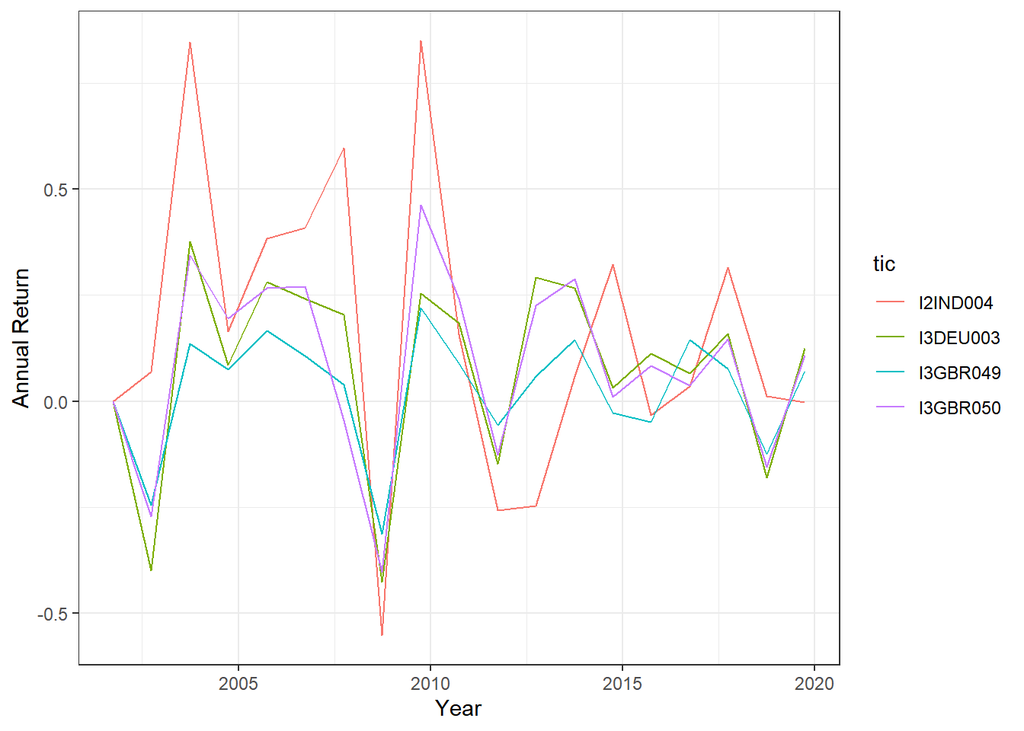

```r
# use pipeline of ggplot
# filter the data and only plot the first 4 indices
library(ggplot2)
p = ret.index %>%
  filter(tic %in% unique(tic)[1:4]) %>%
  ggplot(aes(x=as.Date(year,"%Y"),
               y=ret,
               color=tic))+
  geom_line()+
  labs(x='Year', y = 'Annual Return')+
  theme(legend.position="bottom")+
  theme_bw()
print(p)
```

* Globally, all markets tend to move together. * In 2008, there’s a big drawdown for all indices.

## Visualize returns on multiple charts using facet_wrap

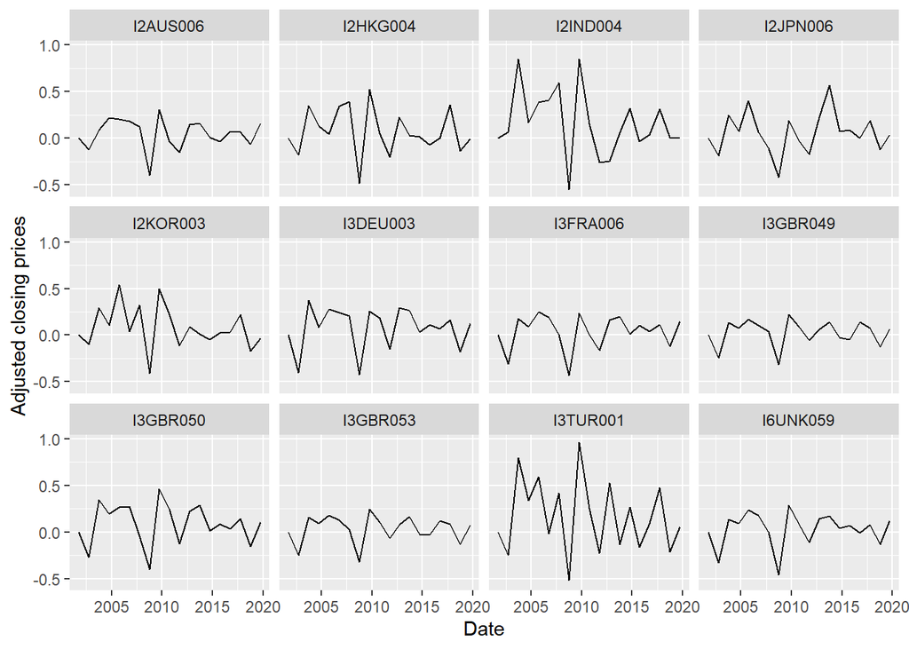

```r
p = ret.index %>%
  ggplot(aes(x = as.Date(year,"%Y"), y = ret)) +
  geom_line() +
  labs(x = 'Date',
       y = 'Adjusted closing prices') +
  facet_wrap(facets = ~tic)
print(p)
```

# Step 5: Check the correlations among indices

```r
# turn long df to wide and remove year col
ret.wide = ret.index %>%
  select(year,tic,ret) %>%
  spread(tic, ret, drop = TRUE) %>%
  select(-year)
ret.wide[1:5,1:5]
```

```
## # A tibble: 5 x 5
##   I2AUS006 I2HKG004 I2IND004 I2JPN006 I2KOR003
##      <dbl>    <dbl>    <dbl>    <dbl>    <dbl>
## 1   0        0        0        0        0
## 2  -0.125   -0.182    0.0690  -0.186   -0.0954
## 3   0.0845   0.349    0.847    0.245    0.292
## 4   0.217    0.132    0.164    0.0761   0.105
## 5   0.203    0.0454   0.383    0.402    0.540
```

```r
# turn to matrix
ret.mat = as.matrix(ret.wide)

# check missing value
any(is.na(ret.mat))
```

```
## [1] FALSE
```

```r
# calculate the correlation matrix and summarise the correlation matrix
summary(cor(ret.mat))
```

```
##     I2AUS006         I2HKG004         I2IND004         I2JPN006
##  Min.   :0.6540   Min.   :0.5328   Min.   :0.4373   Min.   :0.4373
##  1st Qu.:0.7442   1st Qu.:0.7654   1st Qu.:0.6184   1st Qu.:0.5896
##  Median :0.8354   Median :0.7796   Median :0.6381   Median :0.7812
##  Mean   :0.8269   Mean   :0.7844   Mean   :0.6835   Mean   :0.7279
##  3rd Qu.:0.8900   3rd Qu.:0.8111   3rd Qu.:0.7794   3rd Qu.:0.8214
##  Max.   :1.0000   Max.   :1.0000   Max.   :1.0000   Max.   :1.0000
##     I2KOR003         I3DEU003         I3FRA006         I3GBR049
##  Min.   :0.6032   Min.   :0.6213   Min.   :0.5867   Min.   :0.6311
##  1st Qu.:0.7554   1st Qu.:0.7922   1st Qu.:0.7460   1st Qu.:0.7684
##  Median :0.7747   Median :0.8667   Median :0.9143   Median :0.8957
##  Mean   :0.7826   Mean   :0.8496   Mean   :0.8537   Mean   :0.8542
##  3rd Qu.:0.7881   3rd Qu.:0.9288   3rd Qu.:0.9388   3rd Qu.:0.9232
##  Max.   :1.0000   Max.   :1.0000   Max.   :1.0000   Max.   :1.0000
##     I3GBR050         I3GBR053         I3TUR001         I6UNK059
##  Min.   :0.6389   Min.   :0.6374   Min.   :0.5488   Min.   :0.6097
##  1st Qu.:0.7705   1st Qu.:0.7848   1st Qu.:0.7254   1st Qu.:0.7609
##  Median :0.8831   Median :0.9063   Median :0.7494   Median :0.9172
##  Mean   :0.8556   Mean   :0.8658   Mean   :0.7654   Mean   :0.8613
##  3rd Qu.:0.9355   3rd Qu.:0.9490   3rd Qu.:0.7912   3rd Qu.:0.9511
##  Max.   :1.0000   Max.   :1.0000   Max.   :1.0000   Max.   :1.0000
```

- As expected, the matrix of returns has a strong correlation in between the columns.
- In practice, when one market goes up in value, the others tend to follow.
- The economic reasoning is that, given the effects of international commerce and globalization, when an economic shock is seen in one #market, it tends to spread to others.

# Step 6. Calculate the cumulative returns

## We use tapply function rather than the group_by function from dplyr

- The tapply function is useful when we need to break up a vector into groups defined by some classifying factor, compute a function on the subsets, and return the results in a convenient form.
- You can specify multiple factors as the grouping variable
- When the results are vectors, the returned results from tapply is an array

```r
ret.arr = tapply(ret.index$ret, INDEX=ret.index$tic,
         FUN=function(x) cumprod(x+1))
class(ret.arr)
```

```
## [1] "array"
```

```r
str(ret.arr)
```

```
## List of 12
##  $ I2AUS006: num [1:19] 1 0.875 0.949 1.155 1.389 ...
##  $ I2HKG004: num [1:19] 1 0.818 1.103 1.249 1.305 ...
##  $ I2IND004: num [1:19] 1 1.07 1.97 2.3 3.18 ...
##  $ I2JPN006: num [1:19] 1 0.814 1.013 1.09 1.528 ...
##  $ I2KOR003: num [1:19] 1 0.905 1.169 1.292 1.988 ...
##  $ I3DEU003: num [1:19] 1 0.601 0.826 0.896 1.149 ...
##  $ I3FRA006: num [1:19] 1 0.689 0.809 0.884 1.107 ...
##  $ I3GBR049: num [1:19] 1 0.755 0.858 0.923 1.077 ...
##  $ I3GBR050: num [1:19] 1 0.727 0.977 1.168 1.481 ...
##  $ I3GBR053: num [1:19] 1 0.752 0.872 0.952 1.124 ...
##  $ I3TUR001: num [1:19] 1 0.752 1.351 1.812 2.886 ...
##  $ I6UNK059: num [1:19] 1 0.675 0.768 0.84 1.038 ...
##  - attr(*, "dim")= int 12
##  - attr(*, "dimnames")=List of 1
##   ..$ : chr [1:12] "I2AUS006" "I2HKG004" "I2IND004" "I2JPN006" ...
```

## Add the cumulative return as a column back to the ret.index

- Use unlist() will turn the array into a long vector.
- unlist() the array, we will lost the tickers in the vector. # Function tapply orders its output alphabetically, therefore, the order of data in the vector is not matching the original data.

```r
head(unlist(ret.arr))
```

```
## I2AUS0061 I2AUS0062 I2AUS0063 I2AUS0064 I2AUS0065 I2AUS0066
## 1.0000000 0.8749276 0.9488998 1.1550521 1.3891575 1.6430950
```

- We first sorts ret.arr by tic and then add the column in ret.index
- Use unlist() to turn an array back to a long vector

```r
# order the array based on the tic order in ret.index
ret.arr = ret.arr[unique(ret.index$tic)]
# unlist the cumulative return and add it as new column to ret.index
ret.index$cumret = unlist(ret.arr)
head(ret.index)
```

```
## # A tibble: 6 x 7
##   gvkeyx year  last.price     ret conm                tic      cumret
##   <chr>  <chr>      <dbl>   <dbl> <chr>               <chr>     <dbl>
## 1 150007 2001        417.  0      Composite DAX Index I3DEU003  1
## 2 150007 2002        251. -0.399  Composite DAX Index I3DEU003  0.601
## 3 150007 2003        345.  0.376  Composite DAX Index I3DEU003  0.826
## 4 150007 2004        374.  0.0847 Composite DAX Index I3DEU003  0.896
## 5 150007 2005        480.  0.282  Composite DAX Index I3DEU003  1.15
## 6 150007 2006        595.  0.241  Composite DAX Index I3DEU003  1.43
```

```r
# check that the order indeed matches
head(ret.index$cumret)
```

```
## [1] 1.0000000 0.6005989 0.8262817 0.8962386 1.1489938 1.4257547
```

```r
head(ret.arr[[ret.index$tic[1]]])
```

```
## [1] 1.0000000 0.6005989 0.8262817 0.8962386 1.1489938 1.4257547
```

# Step 7. Visualized the cumulative returns

- theme_bw() is making the background color white

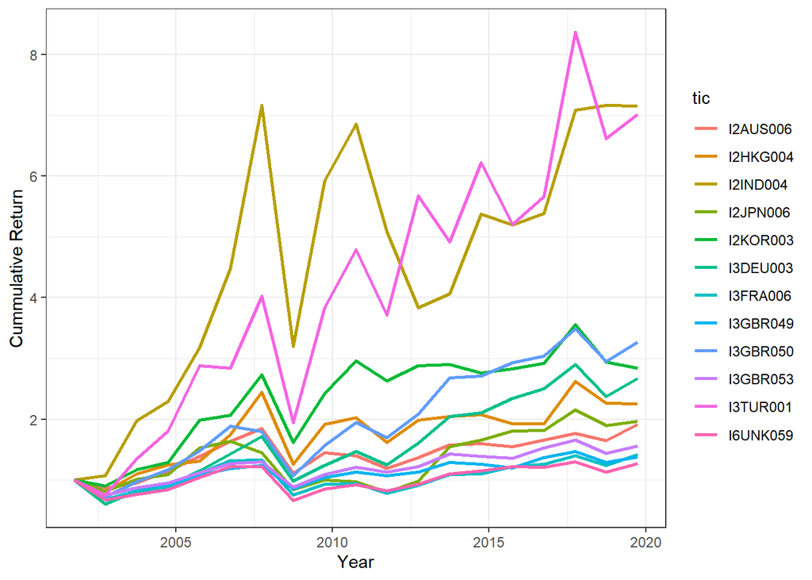

```r
p = ggplot(ret.index,
           aes(x=as.Date(year,"%Y"),
               y=cumret,
               color=tic)) +
  geom_line(size=1) +
  labs(x='Year', y="Cummulative Return") +
  theme(legend.position = "bottom") +
  theme_bw()
print(p)
```

# Step 8. Calculate the average return, standard deviation, and sharpe ratio

```r
ret.summary = ret.index %>% group_by(tic) %>%
  summarise(mean.ret = mean(ret),
            sd.ret = sd(ret),
            sharpe = mean.ret/sd.ret) %>%
  arrange(-sharpe)

ret.summary
```

```
## # A tibble: 12 x 4
##    tic      mean.ret sd.ret sharpe
##    <chr>       <dbl>  <dbl>  <dbl>
##  1 I2IND004   0.165   0.357  0.462
##  2 I3TUR001   0.172   0.392  0.440
##  3 I3GBR050   0.0882  0.221  0.399
##  4 I3DEU003   0.0803  0.226  0.356
##  5 I2KOR003   0.0801  0.229  0.350
##  6 I2AUS006   0.0488  0.163  0.299
##  7 I2HKG004   0.0733  0.247  0.297
##  8 I2JPN006   0.0593  0.223  0.266
##  9 I3GBR053   0.0346  0.146  0.236
## 10 I3FRA006   0.0372  0.184  0.203
## 11 I3GBR049   0.0271  0.138  0.196
## 12 I6UNK059   0.0319  0.184  0.173
```

# Step 9. Visualize the mean variance chart

- geom_point() to generate a dotted chart
- annotate(‘text’,x,y,label) to add names indicators on to each point, x and y are the location of text, label is the text on the chart

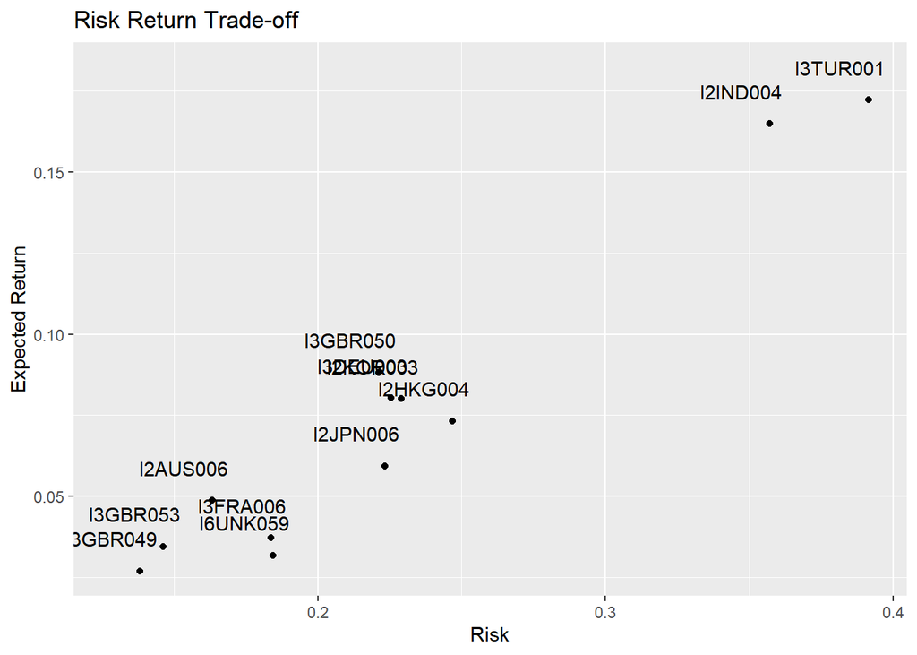

```r
p = ggplot(ret.summary,aes(x=sd.ret,y=mean.ret)) +
  geom_point() +
  annotate('text', x = ret.summary$sd.ret-0.01,
           y = ret.summary$mean.ret+0.01,
           label = ret.summary$tic) +
  labs(x='Risk', y='Expected Return',title='Risk Return Trade-off')
print(p)
```

# Step 10. Build up a portfolio that maximise the Sharpe Ratio

## Use fportfolio package, which search over different combinations of weights and find the weights that maximize the portfolio sharpe ratio

- To use optimiser, we need to make sure that our covariance matrix of returns is positive-definite and has no NA values.
- If this is not true, we won’t be able to run the optimization procedure.
- Use the function is.positive.definite() from package matrixcalc to check the positive definite

```r
library(matrixcalc)
# check if covariance matrix is positive definite
print(is.positive.definite(cov(ret.mat)))
```

```
## [1] TRUE
```

```r
# check for na
print(any(is.na(ret.mat)))
```

```
## [1] FALSE
```

- In fact, the covariance are always positive definite unless one variable is an exact linear function of the others, which is unlikely in real data

## Use function tangencyPortfolio() to get the portfolio with highest sharpe ratio.

- The input must be a return matrix in the timeSeries Class

```r
library(fPortfolio)
# make the ret.mat as a timeseries data
ret.mat = as.timeSeries(ret.mat)
ret.mat[1:3,1:3]
```

```
##
##         I2AUS006   I2HKG004   I2IND004
## [1,]  0.00000000  0.0000000 0.00000000
## [2,] -0.12507238 -0.1821428 0.06900117
## [3,]  0.08454666  0.3491630 0.84713487
```

```r
class(ret.mat)
```

```
## [1] "timeSeries"
## attr(,"package")
## [1] "timeSeries"
```

```r
# get port composition for max sharpe ratio
eff.port = tangencyPortfolio(ret.mat)

# print result
print(eff.port)
```

```
##
## Title:
##  MV Tangency Portfolio
##  Estimator:         covEstimator
##  Solver:            solveRquadprog
##  Optimize:          minRisk
##  Constraints:       LongOnly
##
## Portfolio Weights:
## I2AUS006 I2HKG004 I2IND004 I2JPN006 I2KOR003 I3DEU003 I3FRA006 I3GBR049
##   0.0000   0.0000   0.4815   0.0000   0.0000   0.0000   0.0000   0.0000
## I3GBR050 I3GBR053 I3TUR001 I6UNK059
##   0.3255   0.0000   0.1930   0.0000
##
## Covariance Risk Budgets:
## I2AUS006 I2HKG004 I2IND004 I2JPN006 I2KOR003 I3DEU003 I3FRA006 I3GBR049
##   0.0000   0.0000   0.5616   0.0000   0.0000   0.0000   0.0000   0.0000
## I3GBR050 I3GBR053 I3TUR001 I6UNK059
##   0.2032   0.0000   0.2352   0.0000
##
## Target Returns and Risks:
##   mean    Cov   CVaR    VaR
## 0.1413 0.2910 0.4971 0.4971
##
## Description:
##  Sat Sep 28 15:52:01 2019 by user: siche
```

```r
# get weights of efficient port
wgt = eff.port@portfolio@portfolio$weights
as.data.frame(wgt)
```

```
##                wgt
## I2AUS006 0.0000000
## I2HKG004 0.0000000
## I2IND004 0.4815032
## I2JPN006 0.0000000
## I2KOR003 0.0000000
## I3DEU003 0.0000000
## I3FRA006 0.0000000
## I3GBR049 0.0000000
## I3GBR050 0.3254975
## I3GBR053 0.0000000
## I3TUR001 0.1929993
## I6UNK059 0.0000000
```

```r
wgt = matrix(wgt,nrow=length(wgt))
wgt
```

```
##            [,1]
##  [1,] 0.0000000
##  [2,] 0.0000000
##  [3,] 0.4815032
##  [4,] 0.0000000
##  [5,] 0.0000000
##  [6,] 0.0000000
##  [7,] 0.0000000
##  [8,] 0.0000000
##  [9,] 0.3254975
## [10,] 0.0000000
## [11,] 0.1929993
## [12,] 0.0000000
```

- The portfolio allocate a lot of weights to IND, GBR and TUR as expected.

# Step 11: Calculate the returns of the portfolio, present the summary data

```r
# create a vector with portfolio returns
port = as.matrix(ret.mat) %*% wgt
head(port)
```

```
##            [,1]
## [1,]  0.0000000
## [2,] -0.1033389
## [3,]  0.6732882
## [4,]  0.2085640
## [5,]  0.3862329
## [6,]  0.2822776
```

```r
# get sharpe ratio
sharpe = mean(port)/sd(port)
sharpe
```

```
## [1] 0.4856636
```

# Step 12: Plot the efficient frontier

## Use the portfolioFrontier() function to get the efficient frontier results

## Use tailoredFrontierPlot() to plot the efficient frontierin our mean-variance graph

[figure not shown]

```r
# get eff frontier
eff = portfolioFrontier(data = ret.mat)
# plot it
tailoredFrontierPlot(object = eff,
                     risk = 'Sigma',
                     twoAssets = FALSE,
                     sharpeRatio = FALSE)
```